# examples_0129

Consider the two curves defined algebraically and graphed below.

$$y=2+\sqrt{12x-36}$$
$$y=2x-3$$

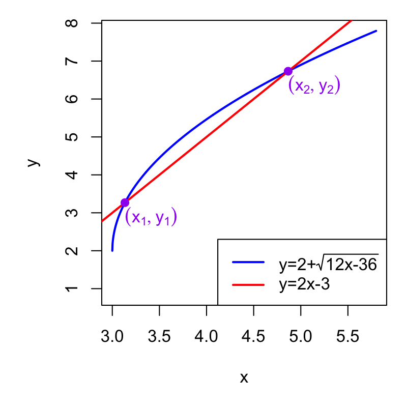

The horizontal coordinates of the intersections, $x_1$ and $x_2$, are also the solutions to the equation below:

$$2+\sqrt{12x-36}=2x-3$$

Solve that equation.

$x=\frac{-47\pm\sqrt{13}}{18}$$x=\frac{-39\pm\sqrt{65}}{8}$$x=\frac{-11\pm\sqrt{21}}{4}$$x=\frac{43\pm\sqrt{105}}{8}$$x=\frac{-25\pm\sqrt{33}}{8}$$x=\frac{49\pm\sqrt{65}}{8}$$x=\frac{8\pm\sqrt{3}}{2}$$x=\frac{79\pm\sqrt{13}}{18}$

$$2+\sqrt{12x-36}=2x-3$$

Subtract 2 from both sides.

$$\sqrt{12x-36}=2x-5$$

Square both sides.
$$12x-36=(2x-5)^2$$

Expand the right side.
$$12x-36=4x^2-20x+25$$

Subtract $12x-36$ from both sides.
$$0=4x^2-32x+61$$

Use the quadratic formula.

$$x=\frac{-(-32)\pm\sqrt{(-32)^2-4(4)(61)}}{2(4)}$$

Simplify.
$$x=\frac{32\pm\sqrt{1024-976}}{8}$$

Simplify.
$$x=\frac{32\pm\sqrt{48}}{8}$$

Simplify the radical.
$$x=\frac{32\pm4\sqrt{3}}{8}$$

Simplify based on common factor of 4.

$$x=\frac{8\pm\sqrt{3}}{2}$$

Consider the two curves defined algebraically and graphed below.

$$y=6+\sqrt{14x-70}$$
$$y=3x-8$$

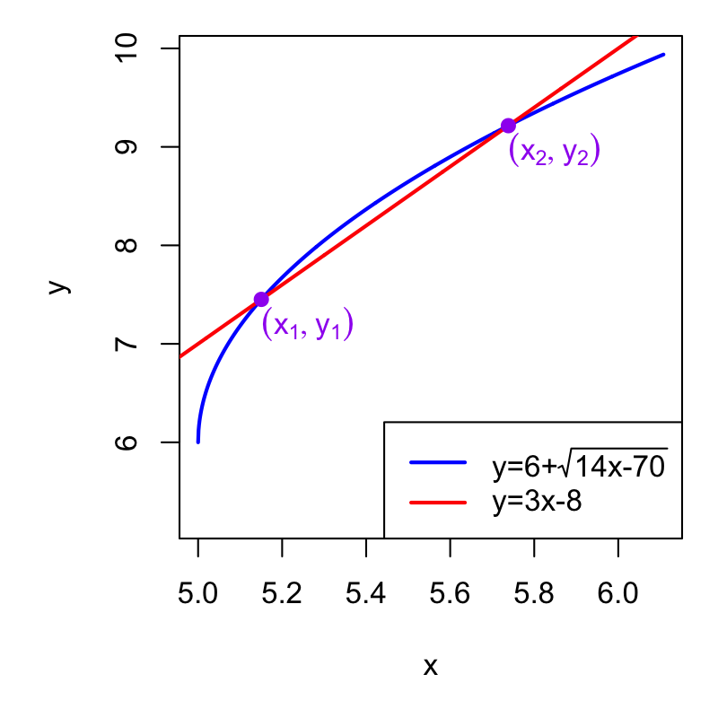

The horizontal coordinates of the intersections, $x_1$ and $x_2$, are also the solutions to the equation below:

$$6+\sqrt{14x-70}=3x-8$$

Solve that equation.

$x=\frac{49\pm\sqrt{7}}{9}$$x=\frac{23\pm\sqrt{33}}{8}$$x=\frac{-33\pm\sqrt{33}}{8}$$x=\frac{-6\pm\sqrt{3}}{2}$$x=\frac{35\pm\sqrt{105}}{8}$$x=\frac{21\pm\sqrt{5}}{6}$$x=\frac{53\pm{3}}{8}$$x=\frac{43\pm\sqrt{105}}{8}$

$$6+\sqrt{14x-70}=3x-8$$

Subtract 6 from both sides.

$$\sqrt{14x-70}=3x-14$$

Square both sides.
$$14x-70=(3x-14)^2$$

Expand the right side.
$$14x-70=9x^2-84x+196$$

Subtract $14x-70$ from both sides.
$$0=9x^2-98x+266$$

Use the quadratic formula.

$$x=\frac{-(-98)\pm\sqrt{(-98)^2-4(9)(266)}}{2(9)}$$

Simplify.
$$x=\frac{98\pm\sqrt{9604-9576}}{18}$$

Simplify.
$$x=\frac{98\pm\sqrt{28}}{18}$$

Simplify the radical.
$$x=\frac{98\pm2\sqrt{7}}{18}$$

Simplify based on common factor of 2.

$$x=\frac{49\pm\sqrt{7}}{9}$$

Consider the two curves defined algebraically and graphed below.

$$y=5+\sqrt{9x-54}$$
$$y=2x-6$$

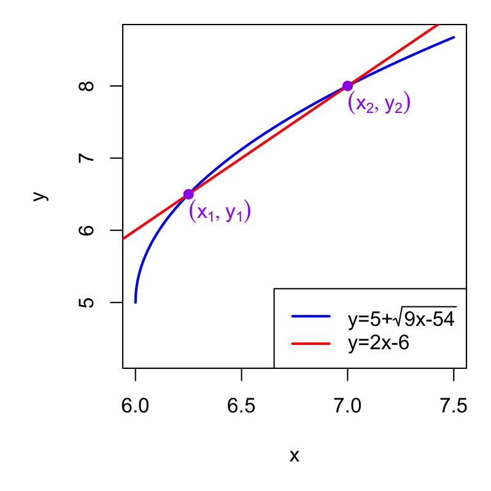

The horizontal coordinates of the intersections, $x_1$ and $x_2$, are also the solutions to the equation below:

$$5+\sqrt{9x-54}=2x-6$$

Solve that equation.

$x=\frac{31\pm\sqrt{7}}{9}$$x=\frac{61\pm\sqrt{13}}{18}$$x=\frac{10\pm\sqrt{3}}{2}$$x=\frac{-7\pm\sqrt{65}}{8}$$x=\frac{97\pm\sqrt{13}}{18}$$x=\frac{-23\pm\sqrt{7}}{9}$$x=\frac{53\pm{3}}{8}$$x=\frac{-23\pm\sqrt{65}}{8}$

$$5+\sqrt{9x-54}=2x-6$$

Subtract 5 from both sides.

$$\sqrt{9x-54}=2x-11$$

Square both sides.
$$9x-54=(2x-11)^2$$

Expand the right side.
$$9x-54=4x^2-44x+121$$

Subtract $9x-54$ from both sides.
$$0=4x^2-53x+175$$

Use the quadratic formula.

$$x=\frac{-(-53)\pm\sqrt{(-53)^2-4(4)(175)}}{2(4)}$$

Simplify.
$$x=\frac{53\pm\sqrt{2809-2800}}{8}$$

Simplify.
$$x=\frac{53\pm\sqrt{9}}{8}$$

Simplify the radical.
$$x=\frac{53\pm3}{8}$$

Consider the two curves defined algebraically and graphed below.

$$y=-2+\sqrt{11x+44}$$
$$y=2x+7$$

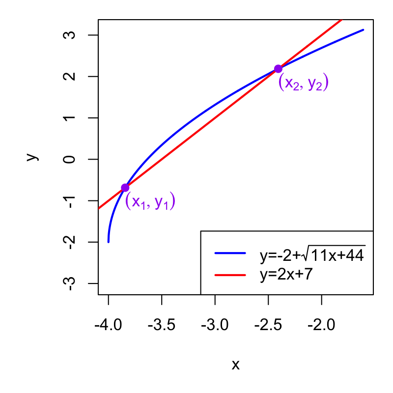

The horizontal coordinates of the intersections, $x_1$ and $x_2$, are also the solutions to the equation below:

$$-2+\sqrt{11x+44}=2x+7$$

Solve that equation.

$x=\frac{37\pm{3}}{8}$$x=\frac{35\pm\sqrt{105}}{8}$$x=\frac{27\pm\sqrt{5}}{4}$$x=\frac{11\pm\sqrt{5}}{4}$$x=\frac{-5\pm\sqrt{105}}{8}$$x=\frac{25\pm\sqrt{65}}{8}$$x=\frac{-25\pm\sqrt{33}}{8}$$x=\frac{-39\pm\sqrt{65}}{8}$

$$-2+\sqrt{11x+44}=2x+7$$

Add 2 to both sides.

$$\sqrt{11x+44}=2x+9$$

Square both sides.
$$11x+44=(2x+9)^2$$

Expand the right side.
$$11x+44=4x^2+36x+81$$

Subtract $11x+44$ from both sides.
$$0=4x^2+25x+37$$

Use the quadratic formula.

$$x=\frac{-(25)\pm\sqrt{(25)^2-4(4)(37)}}{2(4)}$$

Simplify.
$$x=\frac{-25\pm\sqrt{625-592}}{8}$$

Simplify.
$$x=\frac{-25\pm\sqrt{33}}{8}$$

The discriminant, 33, has no perfect-square factors, so we are done simplifying.

Consider the two curves defined algebraically and graphed below.

$$y=-2+\sqrt{15x+30}$$
$$y=2x+3$$

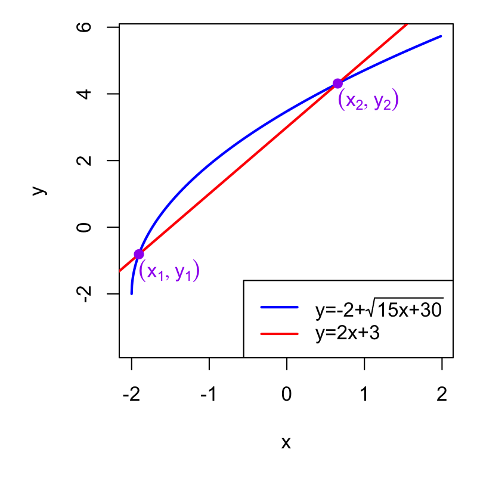

The horizontal coordinates of the intersections, $x_1$ and $x_2$, are also the solutions to the equation below:

$$-2+\sqrt{15x+30}=2x+3$$

Solve that equation.

$x=\frac{-35\pm{3}}{8}$$x=\frac{-4\pm\sqrt{3}}{2}$$x=\frac{31\pm\sqrt{33}}{8}$$x=\frac{79\pm\sqrt{13}}{18}$$x=\frac{10\pm\sqrt{3}}{2}$$x=\frac{-11\pm\sqrt{21}}{4}$$x=\frac{-5\pm\sqrt{105}}{8}$$x=\frac{-23\pm\sqrt{65}}{8}$

$$-2+\sqrt{15x+30}=2x+3$$

Add 2 to both sides.

$$\sqrt{15x+30}=2x+5$$

Square both sides.
$$15x+30=(2x+5)^2$$

Expand the right side.
$$15x+30=4x^2+20x+25$$

Subtract $15x+30$ from both sides.
$$0=4x^2+5x-5$$

Use the quadratic formula.

$$x=\frac{-(5)\pm\sqrt{(5)^2-4(4)(-5)}}{2(4)}$$

Simplify.
$$x=\frac{-5\pm\sqrt{25+80}}{8}$$

Simplify.
$$x=\frac{-5\pm\sqrt{105}}{8}$$

The discriminant, 105, has no perfect-square factors, so we are done simplifying.

Consider the two curves defined algebraically and graphed below.

$$y=6+\sqrt{12x-72}$$
$$y=2x-5$$

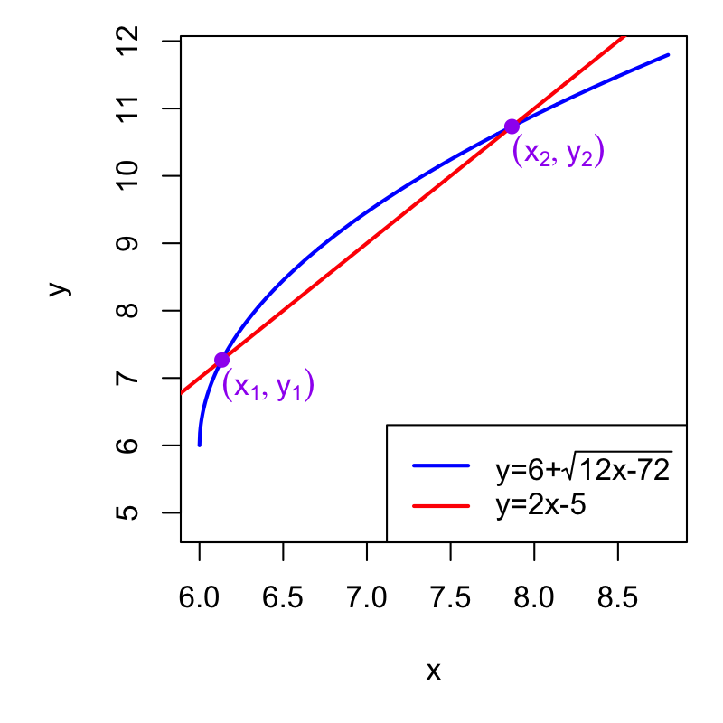

The horizontal coordinates of the intersections, $x_1$ and $x_2$, are also the solutions to the equation below:

$$6+\sqrt{12x-72}=2x-5$$

Solve that equation.

$x=\frac{27\pm\sqrt{5}}{6}$$x=\frac{25\pm\sqrt{21}}{4}$$x=\frac{-9\pm\sqrt{5}}{4}$$x=\frac{59\pm\sqrt{105}}{8}$$x=\frac{29\pm\sqrt{21}}{4}$$x=\frac{21\pm\sqrt{21}}{4}$$x=\frac{14\pm\sqrt{3}}{2}$$x=\frac{35\pm\sqrt{105}}{8}$

$$6+\sqrt{12x-72}=2x-5$$

Subtract 6 from both sides.

$$\sqrt{12x-72}=2x-11$$

Square both sides.
$$12x-72=(2x-11)^2$$

Expand the right side.
$$12x-72=4x^2-44x+121$$

Subtract $12x-72$ from both sides.
$$0=4x^2-56x+193$$

Use the quadratic formula.

$$x=\frac{-(-56)\pm\sqrt{(-56)^2-4(4)(193)}}{2(4)}$$

Simplify.
$$x=\frac{56\pm\sqrt{3136-3088}}{8}$$

Simplify.
$$x=\frac{56\pm\sqrt{48}}{8}$$

Simplify the radical.
$$x=\frac{56\pm4\sqrt{3}}{8}$$

Simplify based on common factor of 4.

$$x=\frac{14\pm\sqrt{3}}{2}$$

Consider the two curves defined algebraically and graphed below.

$$y=5+\sqrt{13x-52}$$
$$y=3x-6$$

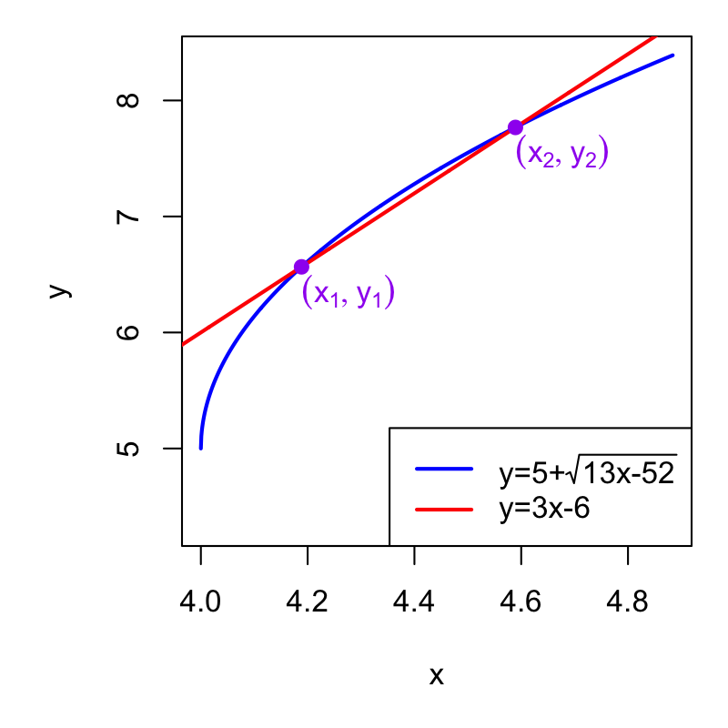

The horizontal coordinates of the intersections, $x_1$ and $x_2$, are also the solutions to the equation below:

$$5+\sqrt{13x-52}=3x-6$$

Solve that equation.

$x=\frac{79\pm\sqrt{13}}{18}$$x=\frac{-5\pm\sqrt{5}}{4}$$x=\frac{59\pm\sqrt{105}}{8}$$x=\frac{-11\pm\sqrt{21}}{4}$$x=\frac{27\pm\sqrt{5}}{4}$$x=\frac{-21\pm\sqrt{5}}{6}$$x=\frac{-10\pm\sqrt{3}}{2}$$x=\frac{11\pm\sqrt{5}}{4}$

$$5+\sqrt{13x-52}=3x-6$$

Subtract 5 from both sides.

$$\sqrt{13x-52}=3x-11$$

Square both sides.
$$13x-52=(3x-11)^2$$

Expand the right side.
$$13x-52=9x^2-66x+121$$

Subtract $13x-52$ from both sides.
$$0=9x^2-79x+173$$

Use the quadratic formula.

$$x=\frac{-(-79)\pm\sqrt{(-79)^2-4(9)(173)}}{2(9)}$$

Simplify.
$$x=\frac{79\pm\sqrt{6241-6228}}{18}$$

Simplify.
$$x=\frac{79\pm\sqrt{13}}{18}$$

The discriminant, 13, has no perfect-square factors, so we are done simplifying.

Consider the two curves defined algebraically and graphed below.

$$y=2+\sqrt{15x+30}$$
$$y=2x+7$$

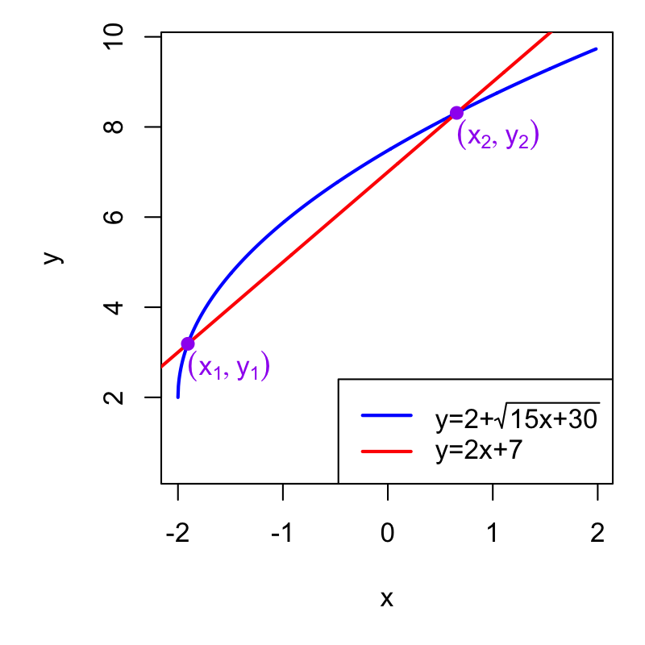

The horizontal coordinates of the intersections, $x_1$ and $x_2$, are also the solutions to the equation below:

$$2+\sqrt{15x+30}=2x+7$$

Solve that equation.

$x=\frac{-11\pm{3}}{8}$$x=\frac{14\pm\sqrt{3}}{2}$$x=\frac{-21\pm\sqrt{5}}{6}$$x=\frac{-5\pm\sqrt{105}}{8}$$x=\frac{12\pm\sqrt{3}}{2}$$x=\frac{41\pm\sqrt{65}}{8}$$x=\frac{55\pm\sqrt{33}}{8}$$x=\frac{51\pm\sqrt{105}}{8}$

$$2+\sqrt{15x+30}=2x+7$$

Subtract 2 from both sides.

$$\sqrt{15x+30}=2x+5$$

Square both sides.
$$15x+30=(2x+5)^2$$

Expand the right side.
$$15x+30=4x^2+20x+25$$

Subtract $15x+30$ from both sides.
$$0=4x^2+5x-5$$

Use the quadratic formula.

$$x=\frac{-(5)\pm\sqrt{(5)^2-4(4)(-5)}}{2(4)}$$

Simplify.
$$x=\frac{-5\pm\sqrt{25+80}}{8}$$

Simplify.
$$x=\frac{-5\pm\sqrt{105}}{8}$$

The discriminant, 105, has no perfect-square factors, so we are done simplifying.

Consider the two curves defined algebraically and graphed below.

$$y=-3+\sqrt{14x+42}$$
$$y=3x+7$$

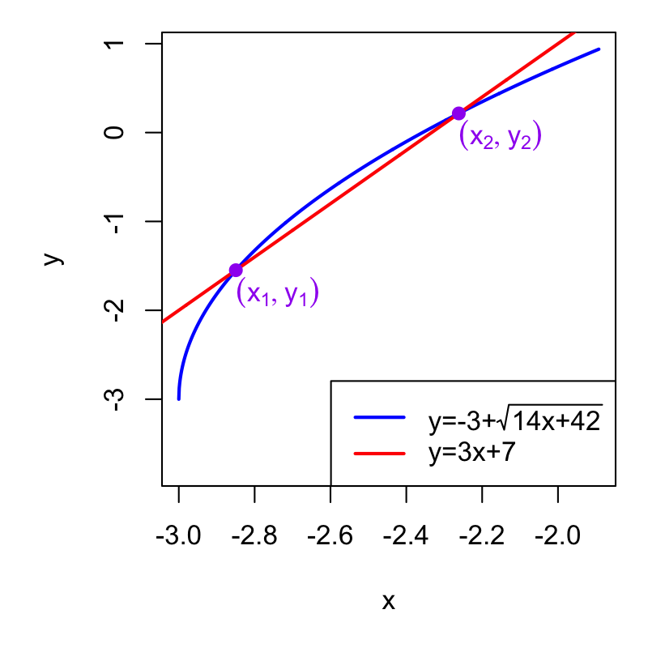

The horizontal coordinates of the intersections, $x_1$ and $x_2$, are also the solutions to the equation below:

$$-3+\sqrt{14x+42}=3x+7$$

Solve that equation.

$x=\frac{-23\pm\sqrt{65}}{8}$$x=\frac{10\pm\sqrt{3}}{2}$$x=\frac{-15\pm\sqrt{21}}{4}$$x=\frac{-21\pm\sqrt{5}}{4}$$x=\frac{-15\pm\sqrt{65}}{8}$$x=\frac{-23\pm\sqrt{7}}{9}$$x=\frac{-19\pm{3}}{8}$$x=\frac{37\pm{3}}{8}$

$$-3+\sqrt{14x+42}=3x+7$$

Add 3 to both sides.

$$\sqrt{14x+42}=3x+10$$

Square both sides.
$$14x+42=(3x+10)^2$$

Expand the right side.
$$14x+42=9x^2+60x+100$$

Subtract $14x+42$ from both sides.
$$0=9x^2+46x+58$$

Use the quadratic formula.

$$x=\frac{-(46)\pm\sqrt{(46)^2-4(9)(58)}}{2(9)}$$

Simplify.
$$x=\frac{-46\pm\sqrt{2116-2088}}{18}$$

Simplify.
$$x=\frac{-46\pm\sqrt{28}}{18}$$

Simplify the radical.
$$x=\frac{-46\pm2\sqrt{7}}{18}$$

Simplify based on common factor of 2.

$$x=\frac{-23\pm\sqrt{7}}{9}$$

Consider the two curves defined algebraically and graphed below.

$$y=-5+\sqrt{15x+60}$$
$$y=3x+8$$

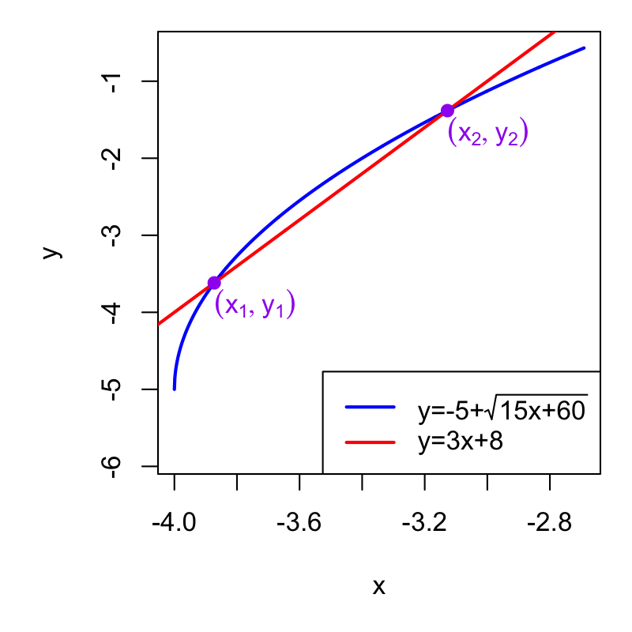

The horizontal coordinates of the intersections, $x_1$ and $x_2$, are also the solutions to the equation below:

$$-5+\sqrt{15x+60}=3x+8$$

Solve that equation.

$x=\frac{49\pm\sqrt{65}}{8}$$x=\frac{12\pm\sqrt{3}}{2}$$x=\frac{57\pm\sqrt{65}}{8}$$x=\frac{14\pm\sqrt{3}}{2}$$x=\frac{51\pm\sqrt{105}}{8}$$x=\frac{-7\pm\sqrt{21}}{4}$$x=\frac{-35\pm{3}}{8}$$x=\frac{-21\pm\sqrt{5}}{6}$

$$-5+\sqrt{15x+60}=3x+8$$

Add 5 to both sides.

$$\sqrt{15x+60}=3x+13$$

Square both sides.
$$15x+60=(3x+13)^2$$

Expand the right side.
$$15x+60=9x^2+78x+169$$

Subtract $15x+60$ from both sides.
$$0=9x^2+63x+109$$

Use the quadratic formula.

$$x=\frac{-(63)\pm\sqrt{(63)^2-4(9)(109)}}{2(9)}$$

Simplify.
$$x=\frac{-63\pm\sqrt{3969-3924}}{18}$$

Simplify.
$$x=\frac{-63\pm\sqrt{45}}{18}$$

Simplify the radical.
$$x=\frac{-63\pm3\sqrt{5}}{18}$$

Simplify based on common factor of 3.

$$x=\frac{-21\pm\sqrt{5}}{6}$$

Consider the two curves defined algebraically and graphed below.

$$y=5+\sqrt{15x-45}$$
$$y=3x-3$$

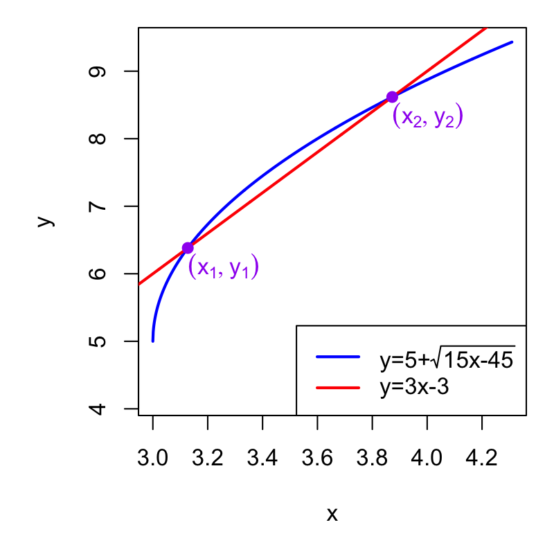

The horizontal coordinates of the intersections, $x_1$ and $x_2$, are also the solutions to the equation below:

$$5+\sqrt{15x-45}=3x-3$$

Solve that equation.

$x=\frac{-15\pm\sqrt{65}}{8}$$x=\frac{59\pm\sqrt{105}}{8}$$x=\frac{21\pm\sqrt{5}}{6}$$x=\frac{-5\pm\sqrt{105}}{8}$$x=\frac{29\pm\sqrt{21}}{4}$$x=\frac{-14\pm\sqrt{7}}{9}$$x=\frac{-21\pm\sqrt{105}}{8}$$x=\frac{-43\pm{3}}{8}$

$$5+\sqrt{15x-45}=3x-3$$

Subtract 5 from both sides.

$$\sqrt{15x-45}=3x-8$$

Square both sides.
$$15x-45=(3x-8)^2$$

Expand the right side.
$$15x-45=9x^2-48x+64$$

Subtract $15x-45$ from both sides.
$$0=9x^2-63x+109$$

Use the quadratic formula.

$$x=\frac{-(-63)\pm\sqrt{(-63)^2-4(9)(109)}}{2(9)}$$

Simplify.
$$x=\frac{63\pm\sqrt{3969-3924}}{18}$$

Simplify.
$$x=\frac{63\pm\sqrt{45}}{18}$$

Simplify the radical.
$$x=\frac{63\pm3\sqrt{5}}{18}$$

Simplify based on common factor of 3.

$$x=\frac{21\pm\sqrt{5}}{6}$$

Consider the two curves defined algebraically and graphed below.

$$y=2+\sqrt{13x-52}$$
$$y=2x-5$$

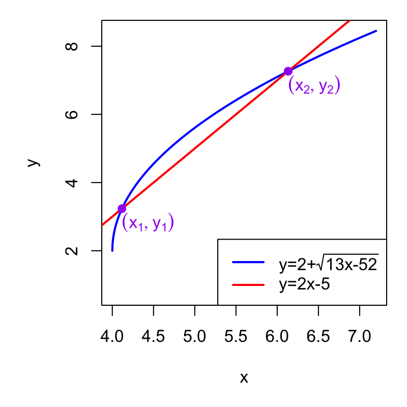

The horizontal coordinates of the intersections, $x_1$ and $x_2$, are also the solutions to the equation below:

$$2+\sqrt{13x-52}=2x-5$$

Solve that equation.

$x=\frac{17\pm\sqrt{21}}{4}$$x=\frac{37\pm{3}}{8}$$x=\frac{21\pm{3}}{8}$$x=\frac{31\pm\sqrt{33}}{8}$$x=\frac{6\pm\sqrt{3}}{2}$$x=\frac{27\pm\sqrt{5}}{4}$$x=\frac{33\pm\sqrt{65}}{8}$$x=\frac{41\pm\sqrt{65}}{8}$

$$2+\sqrt{13x-52}=2x-5$$

Subtract 2 from both sides.

$$\sqrt{13x-52}=2x-7$$

Square both sides.
$$13x-52=(2x-7)^2$$

Expand the right side.
$$13x-52=4x^2-28x+49$$

Subtract $13x-52$ from both sides.
$$0=4x^2-41x+101$$

Use the quadratic formula.

$$x=\frac{-(-41)\pm\sqrt{(-41)^2-4(4)(101)}}{2(4)}$$

Simplify.
$$x=\frac{41\pm\sqrt{1681-1616}}{8}$$

Simplify.
$$x=\frac{41\pm\sqrt{65}}{8}$$

The discriminant, 65, has no perfect-square factors, so we are done simplifying.